# MLOps_lab4_homework

## MLOps lab4 homework

Homework is creating a multimodal similarity search service. It will retrieve images based on a text query, using embeddings from a multimodal model.

### Dataset preparation

```python
import polars as pl
from pathlib import Path

CSV_PATH = "/Users/issi/Documents/MLOps_lab4_homework_data/images/metadata/images.csv.gz"
IMAGES_DIR = Path("/Users/issi/Documents/MLOps_lab4_homework_data/images/small")

df = (
    pl.scan_csv(CSV_PATH)
    .filter(
        (pl.col("width") >= 1000) &
        (pl.col("height") >= 1000) &
        pl.col("path").is_not_null()
    )
    .select(
        (
            pl.lit(str(IMAGES_DIR)) + "/" +
            pl.col("path").str.strip_chars_start("/")
        ).alias("image_path")
    )
    .collect()
)

image_paths = df["image_path"].to_list()
print(image_paths[:10])
```

```
['/Users/issi/Documents/MLOps_lab4_homework_data/images/small/46/4689906d.png', '/Users/issi/Documents/MLOps_lab4_homework_data/images/small/0c/0cd7596c.jpg', '/Users/issi/Documents/MLOps_lab4_homework_data/images/small/e6/e602a9af.jpg', '/Users/issi/Documents/MLOps_lab4_homework_data/images/small/e…
```

### Model Selection and Understanding

```python
import torch
from sentence_transformers import SentenceTransformer

device = "cuda" if torch.cuda.is_available() else "cpu"
model = SentenceTransformer("clip-ViT-B-32", device=device)
```

[output not shown]

**Model:** sentence-transformers/clip-ViT-B-32

**Type:** Multimodal CLIP model — embeds both images and text into a shared 512-dimensional vector space, enabling cross-modal similarity search and zero-shot classification.

**Vector size:** 512 dimensions.

**Model name parts explanation:**

- **ViT** — Vision Transformer: the image encoder architecture. Instead of convolutions, the image is split into fixed-size patches that are processed as a sequence by a Transformer.
- **B** — Base: the model size variant. CLIP comes in several sizes (e.g. Tiny, Small, Base, Large, Huge). Base is a mid-range choice balancing quality and speed.
- **32** — Patch size of 32×32 pixels. Each non-overlapping 32×32 pixel block of the input image becomes one "token" fed into the Transformer encoder. Larger patches → fewer tokens → faster but coarser representation.

### Database setup

```python
from sqlalchemy.engine import URL

db_url = URL.create(
    drivername="postgresql+psycopg",
    username="postgres",
    password="password",
    host="localhost",
    port=5555,
    database="similarity_search_service_db"
)
```

```python
from typing import List
from pgvector.sqlalchemy import Vector
from sqlalchemy import String
from sqlalchemy.orm import DeclarativeBase, Mapped, mapped_column


class Base(DeclarativeBase):
    pass


class Img(Base):
    __tablename__ = "images"
    __table_args__ = {"extend_existing": True}

    VECTOR_LENGTH: int = 512

    id: Mapped[int] = mapped_column(primary_key=True)
    image_path: Mapped[str] = mapped_column(String(256))
    embedding: Mapped[List[float]] = mapped_column(Vector(VECTOR_LENGTH))
```

```python
from sqlalchemy import create_engine

engine = create_engine(db_url)
```

```python
# Create table
Base.metadata.drop_all(engine)
Base.metadata.create_all(engine)
```

### Image vectorization

```python
import joblib
from PIL import Image
from tqdm.notebook import tqdm
from itertools import batched
from sqlalchemy.orm import Session

MAX_IMAGES = 50000
BATCH_SIZE = joblib.cpu_count(only_physical_cores=True)

def insert_images(engine, images):
    with Session(engine) as session:
        session.add_all(images)
        session.commit()


def vectorize_images(engine, model, image_paths):
    image_paths = image_paths[:MAX_IMAGES]

    with tqdm(total=MAX_IMAGES) as pbar:

        for images_paths_batch in batched(image_paths, BATCH_SIZE):

            images = [
                Image.open(path).convert("RGB")
                for path in images_paths_batch
            ]

            # calculate embeddings
            embeddings = model.encode(images, convert_to_numpy=True)

            # create Img instances for all images in batch
            imgs = [
                Img(image_path=str(path), embedding=embedding)
                for path, embedding in zip(images_paths_batch, embeddings)
            ]

            # insert all batch images
            insert_images(engine, imgs)

            # update pbar
            pbar.update(len(imgs))


vectorize_images(engine, model, image_paths)
```

### Search and results display

Searching for the most similar embeddings based on a text description.

```python
import matplotlib.pyplot as plt
from PIL import Image
from sqlalchemy import select
from sqlalchemy.orm import Session


class ImageSearch:
    def __init__(self, engine, model):
        self.engine = engine
        self.model = model

    def __call__(self, image_description: str, k: int = 5):
        found_images = self.find_similar_images(image_description, k)
        self.display_images(found_images, k)

    def find_similar_images(self, image_description: str, k: int):
        image_embedding = self.model.encode(image_description)

        with Session(self.engine) as session:
            query = (
                select(Img.image_path)
                .order_by(Img.embedding.cosine_distance(image_embedding))
                .limit(k)
            )
            result = session.execute(query).scalars().all()
        return result

    def display_images(self, images, k):
        fig, axes = plt.subplots(1, k, figsize=(15, 5))
        if k == 1:
            axes = [axes]

        for i, img_path in enumerate(images):
            img = Image.open(img_path)
            axes[i].imshow(img)
            axes[i].axis("off")
            axes[i].set_title(f"Image {i+1}")

        plt.tight_layout()
        plt.show()


searcher = ImageSearch(engine, model)
```

Checking a few different queries to see if results are relevant.

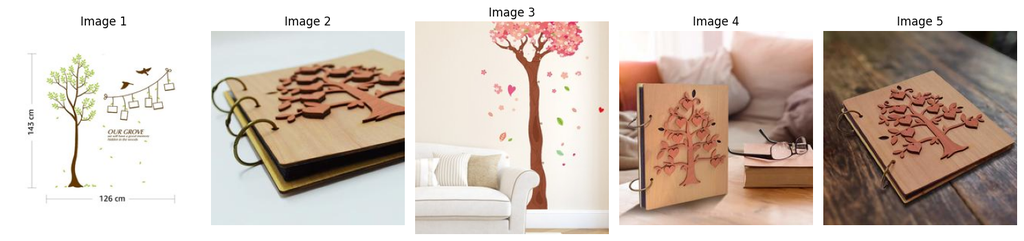

```python
searcher("old tree", k=5)
```

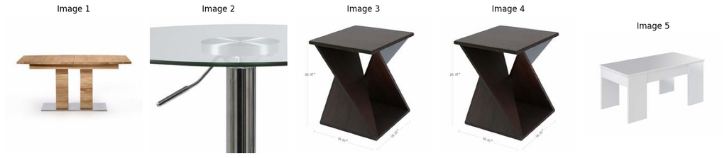

```python
searcher("modern table", k=5)
```

[figure not shown]

```python
searcher("blue coffee mug", k=5)
```

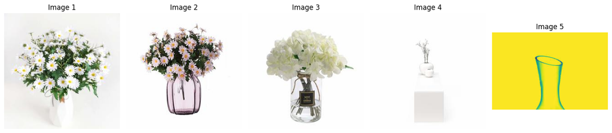

```python
searcher("flower vase", k=5)
```

Results are relevant: CLIP's shared embedding space aligns text and visual concepts quite well.

- "old tree" returns images with trees,
- "modern table" returns furniture with modern lines,
- "blue coffee mug" returns mug-shaped objects with blue colour tones,
- "flower vase" returns tall, narrow vessel-shaped objects, often containing flowers.

Checking 3 different MAX_IMAGES sizes. The experiment below re-runs vectorization for 3 different dataset sizes and compares results for the same query to check if we have more accurate results for larger datasets.

```
==================================================
MAX_IMAGES = 500
==================================================
```

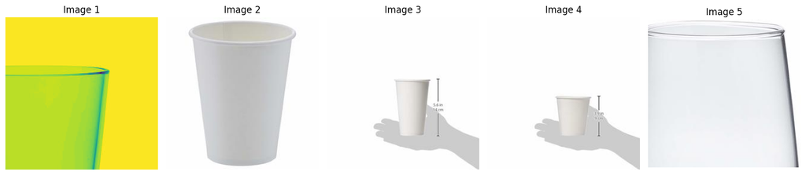

```
==================================================
MAX_IMAGES = 5000
==================================================
```

[figure not shown]

```
==================================================
MAX_IMAGES = 50000
==================================================
```

[figure not shown]

```python
TEST_QUERY = "blue coffee mug"
TEST_K = 5

for max_images in [500, 5000, 50000]:
    print(f"\n{'='*50}")
    print(f"MAX_IMAGES = {max_images}")
    print(f"{'='*50}")
    Base.metadata.drop_all(engine)
    Base.metadata.create_all(engine)
    vectorize_images(engine, model, image_paths[:max_images])
    searcher(TEST_QUERY, k=TEST_K)
```

**Effect of MAX_IMAGES changes on search accuracy:**

With **500 images** the candidate pool is tiny — the search must return something even if nothing closely matches the query, resulting in search results that often fit the query less well or sometimes can even look unrelated.

With **5 000 images** results noticeably improve: the query is more likely to find at least a few genuinely relevant products.

With **50 000 images** the accuracy is clearly better — the larger pool contains more true positives for any given query, so top-k results are consistently on-topic.

**Conclusion:** larger datasets improve retrieval quality because cosine similarity is a nearest-neighbour search — it returns the closest vectors available. A larger pool increases the probability that a genuinely similar image exists in the database. The more images you process, the more accureate results of search you will get.